# Logistic Regression Analysis of Topical and Rhetorical Framing Features

Qi Yu

2023-02-20

```r
library(tidyverse)
library(broom)
library(dplyr)
library(tibble)
library(ggplot2)
library(ggsci)
library(visreg)
library(jtools)
library(lme4)
library(corrplot)
library(Hmisc)
```

# 1. Read in feature statistics

```r
df <- read.csv("/Users/qiyu/PycharmProjects/topical-and-rhetorical-framing/linguistic_annotation_service/results/feature_statistics.tsv", sep="\t", header=TRUE)
save_root = "results/"
```

# 2. Preprocessing

Combine the statistics of all discourse connective types to one feature `connective`:

```r
df$connective <- df$causal + df$consecutive + df$conditional + df$concessive + df$adversative
```

Remove columns that will not be used for logistic regression:

```r
df <- select(df, -c(id, text, text_cleaned,
                    causal, consecutive, conditional, concessive, adversative
                    ))
```

Rearrange the column orders, so that features belonging to the same type and dimension (see Section 4 of the original paper) are groupped together:

```r
col_order <- c("source",
               "arousal", # dimension "arousal"
               "adv_iter_cont", "scalar_particle",# dimension "presupposition"
               "common_ground", "resigned_accept", "weak_commit", # dimension "modal particles"
               "exclamation", "question", # dimension "sentence type"
               "connective", # dimension "information structure"
               "economy", "identity", "legal", "morality", "policy", "politics", "public_opinion", "security", "welfare" # topical framing features
               )

df <- df[, col_order]
```

# 3. Check correlation of the features

```r
res <-rcorr(as.matrix(df[, 2:ncol(df)]), type="spearman")
sort(c(round(as.matrix(res$r), 3)))
```

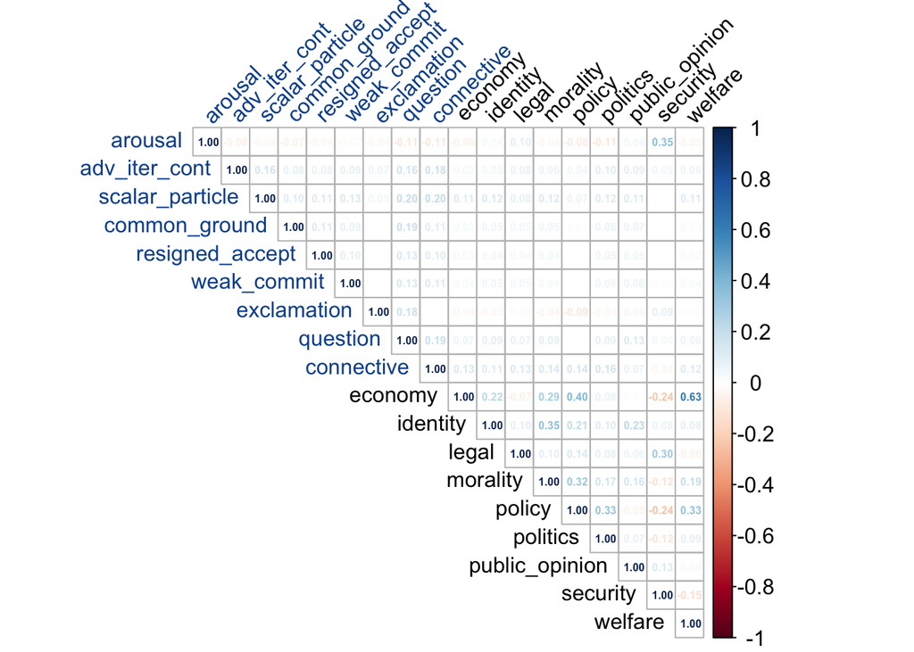

```r
label_col = rep(c("#08519C", "black"), times = c(9, 9))
corrplot(res$r, type="upper", method="number", tl.col = label_col, tl.srt = 45, number.cex= 0.5, tl.cex = 1, cl.cex = 1, mar = c(0, 0, 0, 0))
```

As `economy` and `welfare` show a relatively strong correlation whereas the vocabulary of `economy` has a broader coverage, we discard the feature `welfare`:

```r
df <- select(df, -c(welfare))
```

# 4. Logistic regression

To quantify which features are most distinctive in each newspaper source (BILD, FAZ and SZ), for each source we fit a binary logistic regression model using the source as response variable (e.g., is_BILD = 0 vs.1) and all features as predictors.

Firstly, we create the binary response variable:

```r
df <- df %>%
  mutate(is_bild = if_else(source == 0, "yes", "no"), .after = "source") %>%
  mutate(is_faz = if_else(source == 1, "yes", "no"), .after = is_bild) %>%
  mutate(is_sz = if_else(source == 2, "yes", "no"), .after = is_faz) %>%
  mutate_if(is.character, as.factor) %>%
  mutate(source = factor(source))
```

Standardize all predictors by removing the mean and scaling to unit variance:

```r
x <- df[, 5: ncol(df)] %>%
  mutate_if(is.numeric, scale)
x <- as.data.frame(x)
```

Fit logistic regression model for each newspaper source.

Results of all significant features are written out to the folder /results.

```r
sources <- c("bild", "faz", "sz")

for (s in grep("is_bild", colnames(df)) : grep("is_sz", colnames(df))) {
  y <- df[, s]
  df_logistic <- cbind(y, x)

  model <- glm(y ~ ., data = df_logistic, family = 'binomial')
  print(summary(model))

  result <- tidy(model) %>%
    mutate_if(is.numeric, round, digits=5)

  result <- result[order(result$statistic, decreasing=TRUE), ]
  write.csv(result[result$p.value < 0.05, ], paste(save_root, "logistic_regression_", sources[s-1], ".csv", sep = ""), row.names=FALSE)
}
```

```
##
## Call:
## glm(formula = y ~ ., family = "binomial", data = df_logistic)
##
## Deviance Residuals:
##    Min      1Q  Median      3Q     Max
## -5.889  -1.024   0.002   1.112   5.104
##
## Coefficients:
##                  Estimate Std. Error z value Pr(>|z|)
## (Intercept)      0.843726   0.038952  21.661  < 2e-16 ***
## arousal          0.048039   0.016569   2.899 0.003740 **
## adv_iter_cont    0.043377   0.015288   2.837 0.004550 **
## scalar_particle -0.171302   0.016726 -10.241  < 2e-16 ***
## common_ground   -0.224245   0.027526  -8.147 3.74e-16 ***
## resigned_accept -0.266110   0.033715  -7.893 2.95e-15 ***
## weak_commit     -0.054521   0.015939  -3.421 0.000625 ***
## exclamation      5.145110   0.187187  27.486  < 2e-16 ***
## question         0.068738   0.018217   3.773 0.000161 ***
## connective      -0.408441   0.016561 -24.664  < 2e-16 ***
## economy          0.003934   0.016040   0.245 0.806230
## identity        -0.026159   0.015598  -1.677 0.093514 .
## legal           -0.014213   0.017095  -0.831 0.405742
## morality        -0.101891   0.015966  -6.382 1.75e-10 ***
## policy          -0.019669   0.017817  -1.104 0.269614
## politics        -0.016576   0.015670  -1.058 0.290128
## public_opinion   0.048757   0.015316   3.183 0.001456 **
## security         0.276413   0.019686  14.041  < 2e-16 ***
## ---
## Signif. codes:  0 '***' 0.001 '**' 0.01 '*' 0.05 '.' 0.1 ' ' 1
##
## (Dispersion parameter for binomial family taken to be 1)
##
##     Null deviance: 32307  on 23328  degrees of freedom
## Residual deviance: 26811  on 23311  degrees of freedom
## AIC: 26847
##
## Number of Fisher Scoring iterations: 8
##
##
```

[output cut: 61 more lines]

```
## morality         0.052910   0.017427   3.036 0.002397 **
## policy           0.002191   0.020368   0.108 0.914327
## politics         0.061752   0.017431   3.543 0.000396 ***
## public_opinion   0.006683   0.017350   0.385 0.700088
## security        -0.144829   0.022831  -6.343 2.25e-10 ***
## ---
## Signif. codes:  0 '***' 0.001 '**' 0.01 '*' 0.05 '.' 0.1 ' ' 1
##
## (Dispersion parameter for binomial family taken to be 1)
##
##     Null deviance: 22983  on 23328  degrees of freedom
## Residual deviance: 21297  on 23311  degrees of freedom
## AIC: 21333
##
## Number of Fisher Scoring iterations: 9
```

# 5. Plot logistic regression results:

Read in the result files from Section 4, and group the features into two types (`Topical`, `Rhetorical`) for plotting:

```r
df_bild <- read.csv("./results/logistic_regression_bild.csv") %>%
  mutate(source = "BILD") %>%
  mutate(feature_type = if_else(term %in% c("economy", "identity", "legal", "morality", "policy", "politics", "public_opinion", "security", "welfare"), "Topical", "Rhetorical")) %>%
  filter(term!="(Intercept)")

df_faz <- read.csv("./results/logistic_regression_faz.csv") %>%
   mutate(source = "FAZ") %>%
  mutate(feature_type = if_else(term %in% c("economy", "identity", "legal", "morality", "policy", "politics", "public_opinion", "security", "welfare"), "Topical", "Rhetorical")) %>%
  filter(term!="(Intercept)")

df_sz <- read.csv("./results/logistic_regression_sz.csv") %>%
   mutate(source = "SZ") %>%
  mutate(feature_type = if_else(term %in% c("economy", "identity", "legal", "morality", "policy", "politics", "public_opinion", "security", "welfare"), "Topical", "Rhetorical")) %>%
  filter(term!="(Intercept)")
```

For each newspaper, plot the z-value of each feature. Note that only significant features are included here (see Section 4):

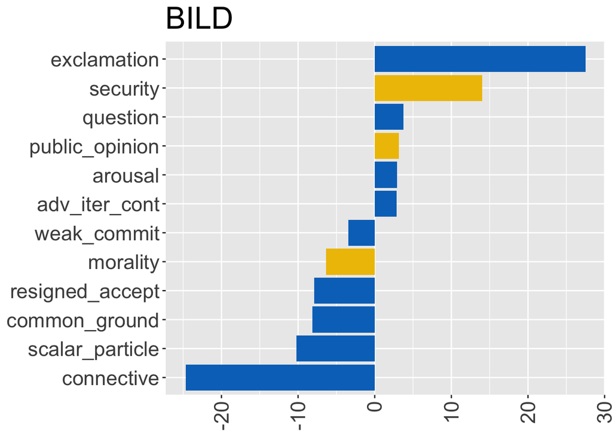

```r
ggplot(df_bild, aes(x = reorder(term, statistic), y = statistic, fill = feature_type)) +
  geom_bar(stat = "identity", position = "dodge") +
  coord_flip() +
  ylab("Z-Score") +
  ggtitle("BILD") +
  scale_fill_jco() +
  theme_grey() +
  theme(axis.text.x = element_text(angle = 90, vjust = 0.5, hjust=1),
        axis.title.x = element_blank(),
        axis.title.y = element_blank(),
        text = element_text(size = 21),
        legend.position = "none")
```

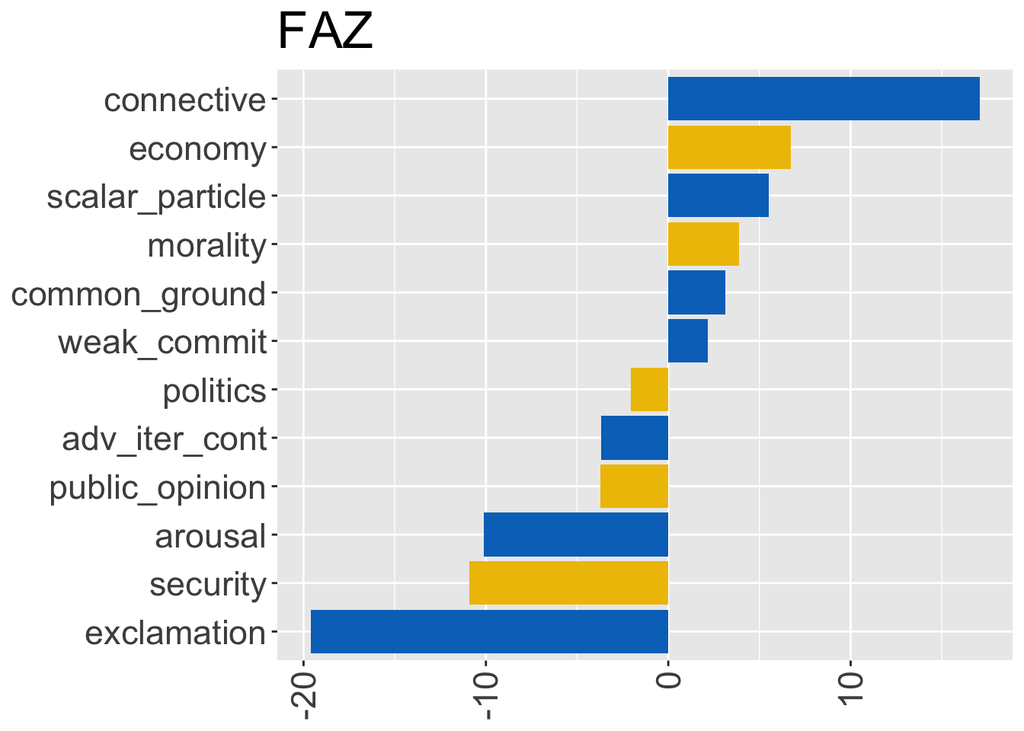

```r
ggplot(df_faz, aes(x = reorder(term, statistic), y = statistic, fill = feature_type)) +
  geom_bar(stat = "identity", position = "dodge") +
  coord_flip() +
  ylab("Z-Score") +
  ggtitle("FAZ") +
  scale_fill_jco() +
  theme_grey() +
  theme(axis.text.x = element_text(angle = 90, vjust = 0.5, hjust=1),
        axis.title.x = element_blank(),
        axis.title.y = element_blank(),
        text = element_text(size = 21),
        legend.position = "none")
```

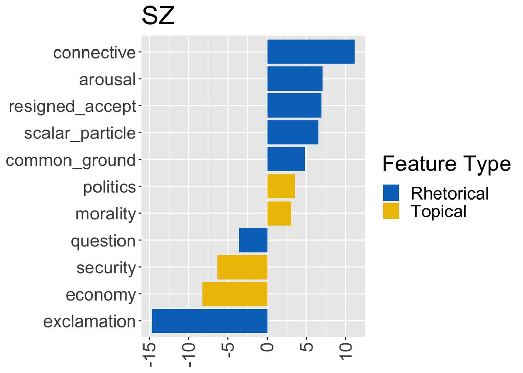

```r
ggplot(df_sz, aes(x = reorder(term, statistic), y = statistic, fill = feature_type)) +
  geom_bar(stat = "identity", position = "dodge") +
  coord_flip() +
  ylab("Z-Score") +
  ggtitle("SZ") +
  scale_fill_jco() +
  theme_grey() +
  theme(axis.text.x = element_text(angle = 90, vjust = 0.5, hjust=1),
        axis.title.x = element_blank(),
        axis.title.y = element_blank(),
        text = element_text(size = 21)) +
  guides(fill=guide_legend(title="Feature Type"))
```